# 320d IMDB Project Report

## Introduction and restatement of requirements

You should introduce your project and restate the project requirements you were given. Approx 2-3 paragraphs.

IMDb is an online database of information related to films, television series, home videos, video games, and streaming content online – including cast, production crew and personal biographies, plot summaries, trivia, ratings, and fan and critical. [IMDB](https://en.wikipedia.org/wiki/IMDb)

We have a set of CSV files from the IMDB (Internet Movie DataBase) that contains movie titles, the genres of those movies, and the directors, actresses, and actors in those movies. We will provide the IMDB VP of Marketing with information on which movies have received the highest ratings over the past few years, which directors, actresses and actors have had the highest average ratings for their movies, and what the highest rated movies in each genre are. Also, we will provide the highest rated movie genre to the IMDB VP of Marketing for decision making.

We are required to answer the following questions:

- What are the top 10 highest rated movies for the last 5 years?
- What directors (with at least 3 movies) have the highest average rating?
- What actresses (with at least 3 movies) have the highest average rating?
- What actors (with at least 3 movies) have the highest average rating?
- What are the 3 highest rated movies in each genre?
- What are the highest rated movie genres?

## Data Ingestion

### Documentation for source data

- Examples of Concrete data
- Conceptual ER
- Physical ER
- Sample tables (screenshots are sufficient)

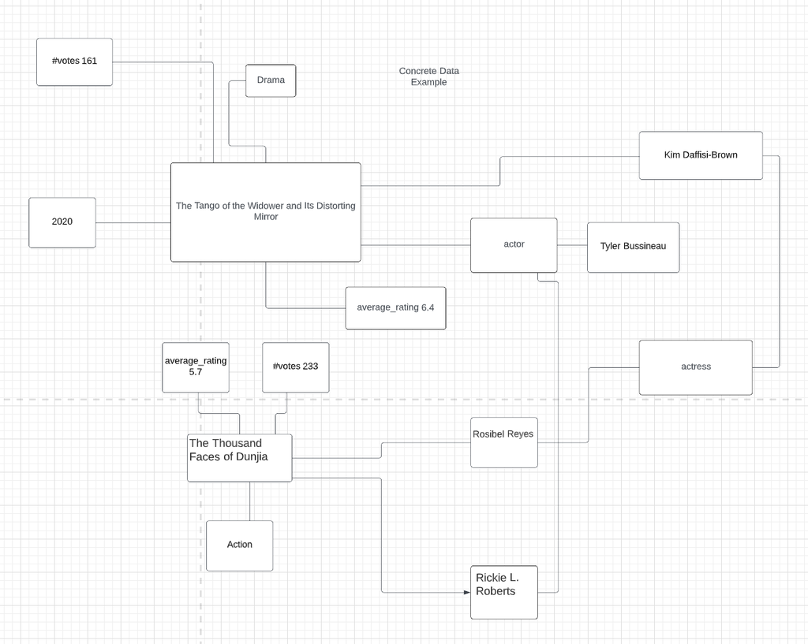

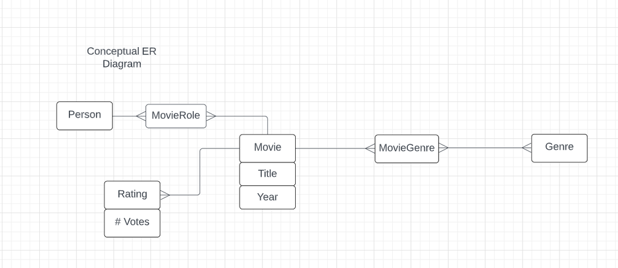

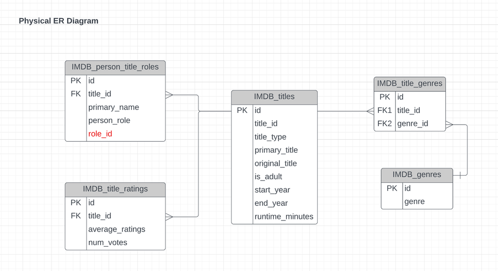

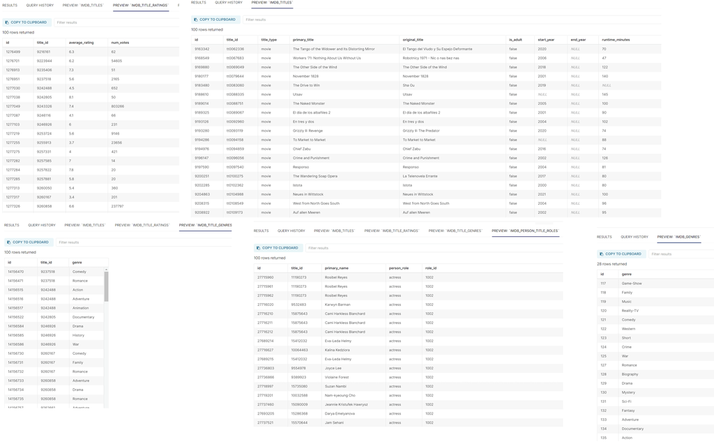

- However, in reality the raw data we were given is flawed. There is no genre_id in IMDB_title_genres connected to IMDB_genres, so in the end we get tables like this, but this problem can be solved later in the star schema stage, because we will directly creat a genres_dimension to represent this feature.
- Another noteworthy point is the role_id marked in red, which does not exist in the original data. We will manually add the role_id in the place of "Load script with \copy commands" to distinguish the actor, the actor, and the director to make the operation more convenient.

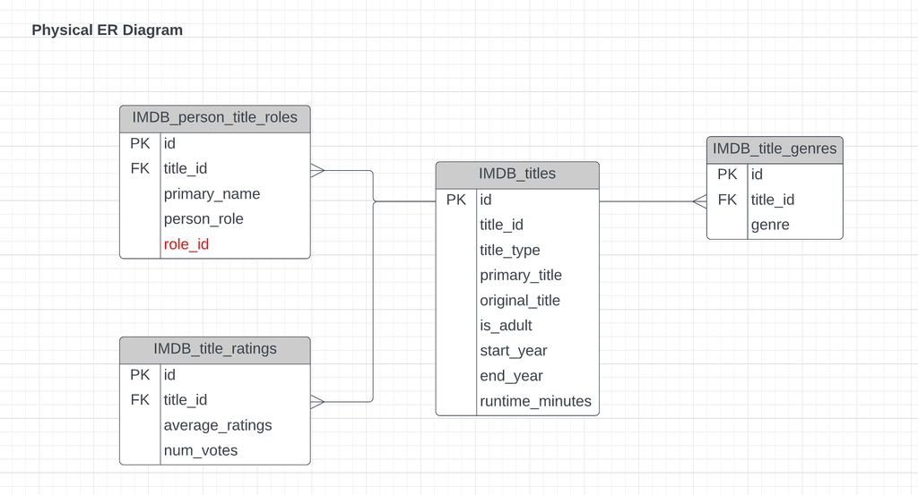

### SQL to create staging tables

Write the SQL scripts to create the tables and describe how those scripts are run. This was introduced when we discussed [Ingestion and Bulk Loading](https://chipzx92.github.io/DataEngineeringI320/presentations/ingestion-pt2/)

```
-- First, have all the DROP TABLE IF EXISTS commands
DROP TABLE IF EXISTS staging.imdb_titles;
DROP TABLE IF EXISTS staging.imdb_title_genres;
DROP TABLE IF EXISTS staging.imdb_title_ratings;
DROP TABLE IF EXISTS staging.imdb_person_title_roles;

-- Then have all of the CREATE TABLE IF NOT EXISTS commands

CREATE TABLE IF NOT EXISTS staging.imdb_titles
(
  id INTEGER PRIMARY KEY,
  title_id TEXT,
  title_type TEXT,
  primary_title TEXT,
  original_title TEXT,
  is_adult BOOLEAN NOT NULL,
  start_year INTEGER,
  end_year INTEGER,
  runtime_minutes INTEGER
);

CREATE TABLE IF NOT EXISTS staging.imdb_title_genres
(
id INTEGER PRIMARY KEY,
title_id INTEGER,
--FOREIGN KEY (title_id) REFERENCES imdb_titles(id),
genre TEXT
);

CREATE TABLE IF NOT EXISTS staging.imdb_title_ratings
(
id INTEGER PRIMARY KEY,
title_id INTEGER,
--FOREIGN KEY (title_id) REFERENCES imdb_titles(id),
average_rating FLOAT,
num_votes INTEGER
);

CREATE TABLE IF NOT EXISTS staging.imdb_person_title_roles
(
id INTEGER PRIMARY KEY,
title_id INTEGER,
--FOREIGN KEY (title_id) REFERENCES imdb_titles(id),
primary_name TEXT,
person_role TEXT
);

DROP TABLE IF EXISTS staging.imdb_genres;
CREATE TABLE IF NOT EXISTS staging.imdb_genres
(
  id INTEGER PRIMARY KEY,
  genre TEXT
);
```

### Load script with \copy commands

Include preformatted Markdown cells with the content of your file with your \copy commands. Show us where the file is and how it is run.

```
TRUNCATE TABLE staging.imdb_titles;
\copy staging.imdb_titles  FROM '../../data/imdb_titles.csv' WITH HEADER CSV;

TRUNCATE TABLE staging.imdb_title_ratings;
\copy staging.imdb_title_ratings  FROM '../../data/imdb_title_ratings.csv' WITH HEADER CSV;

TRUNCATE TABLE staging.imdb_title_genres;
\copy staging.imdb_title_genres  FROM '../../data/imdb_title_genres.csv' WITH HEADER CSV;

TRUNCATE TABLE staging.imdb_person_title_roles;
\copy staging.imdb_person_title_roles  FROM '../../data/imdb_person_title_roles.csv' WITH HEADER CSV;

TRUNCATE TABLE staging.imdb_genres;
\copy staging.imdb_genres  FROM '../../data/imdb_genres.csv' WITH HEADER CSV;


ALTER TABLE imdb_person_title_roles ADD role_id INTEGER;

UPDATE imdb_person_title_roles
   SET role_id = 1001
 WHERE person_role = 'actor';

UPDATE imdb_person_title_roles
   SET role_id = 1002
 WHERE person_role = 'actress';

UPDATE imdb_person_title_roles
   SET role_id = 1003
 WHERE person_role = 'director';
```

- We manually assign the role_id here, and the detailed reason will be explained in the Transformation Diagram section.

## Data Transformation

### Transformation to Star Schema

#### Identify facts, grain, and dimensions

Discuss your data to identify, with reference to the project requirements, the relevant facts, grain and dimensions. Approx 1-2 paragraphs.

- Our database is about imdb movie information, and our task is to find out the top rated movies about actor, actress, director, different genre in the last 5 years. Thus, the essence of our data is the rating information for each genre and each role and each person for each movie. The fact information we picked are role, title, person, genre, as well as rating, number of votes, and year.
- Based on this information, we need to have the genres dimension to provide information about genres, the people dimension to provide information about individuals, the roles dimension to list the three roles (actor, actres, director), the titles dimension to provide movie names, and the ratings dimension to represent each rating for each genre and each role and each person for each movie. From these five dimensions, we integrate the fact table and add the rating score, number of votes, and the release year information in years. This allows us to look up the highest ratings according to the corresponding categories.

#### Transformation diagram

Create and include a transformation diagram, as we did in class in [Dimensional Modeling Pt 2](https://chipzx92.github.io/DataEngineeringI320/presentations/dimensional_modeling-pt2)

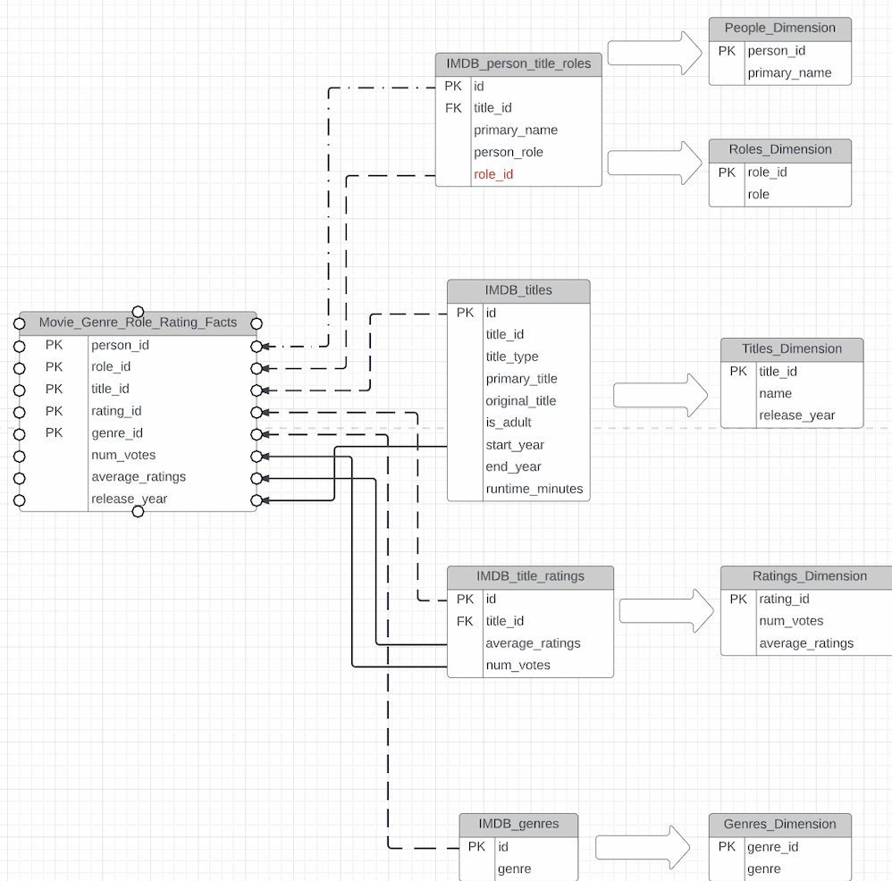

- Note that the raw data we were given was flawed, imdb_person_title_roles does not give unique person_id and role_id. For role_id we could create them manually because there were only three roles, but for person_id there were tens of thousands of people, making it impossible to create them manually.
- We will use the id of imdb_person_title_roles temporarily as person_id as suggested by Chip, the product manager, which results in the same person having multiple different person_id's. In the later data products phase we will use the distinct primary_name of the each person as the actual "person_id" to ensure the uniqueness of each person.

#### Documentation for star schema

- Examples of Concrete data (for the star schema)
- Conceptual ER (for the star schema)
- Physical ER (for the star schema)
- Sample tables (screenshots are sufficient)

[figure not shown]

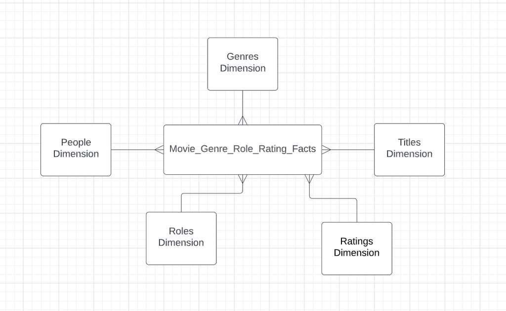

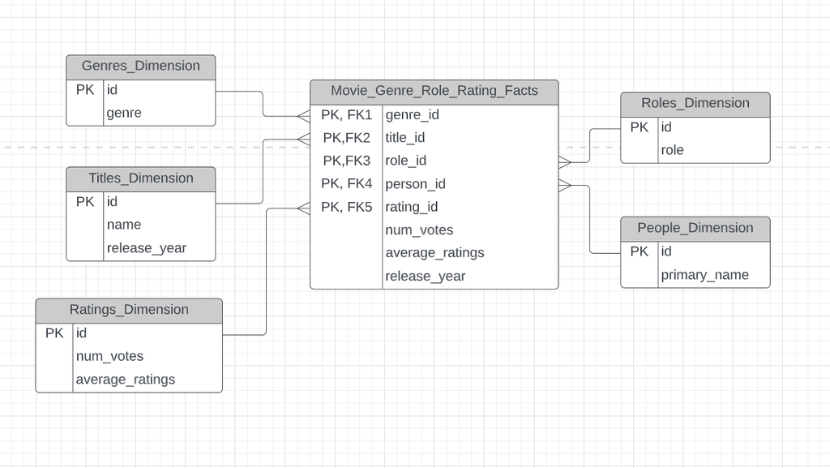

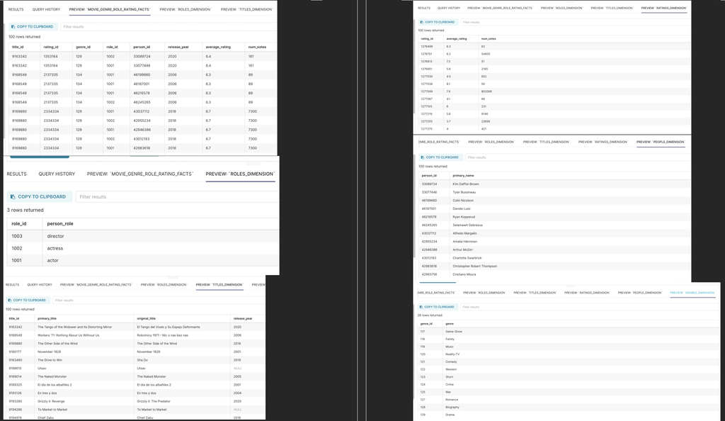

#### dbt models transforming to star schema

Include Markdown cells with the contents of your dbt model files used to create your star schema (fact and dimension tables). These were introduced when we covered [dbt intro](https://chipzx92.github.io/DataEngineeringI320/presentations/dbt_intro/)

- According to Chip, the product manager, we don't need to add references to point to staging tables because there is no corresponding path in the backend.

clean_person_title_roles.sql

```
{{
   config(
     materialized="table"
   )
}}
SELECT MAX(id) AS id, title_id, primary_name, person_role, role_id
FROM staging.imdb_person_title_roles
GROUP BY title_id, primary_name, person_role, role_id
```

- It can be seen that we used MAX, because imdb_person_title_roles has many identical duplicate rows in the original data, only the IDs are different, so we only keep the largest id to delete duplicates under the suggestion of the product manager Chip.

genres_dimension.sql

```
{{
   config(
     materialized="table"
   )
}}
SELECT g.id AS genre_id, g.genre
FROM staging.imdb_genres AS g
```

people_dimension.sql

```
{{
   config(
     materialized="table"
   )
}}
SELECT ptr.id as person_id, ptr.primary_name
FROM {{ ref ('clean_person_title_roles') }} AS ptr
```

ratings_dimension.sql

```
{{
   config(
     materialized="table"
   )
}}
SELECT tr.id AS rating_id, tr.average_rating, tr.num_votes
FROM staging.imdb_title_ratings AS tr
```

roles_dimension.sql

```
{{
   config(
     materialized="table"
   )
}}
SELECT DISTINCT role_id, person_role
FROM {{ ref ('clean_person_title_roles') }} AS ptr
```

titles_dimension.sql

```
{{
   config(
     materialized="table"
   )
}}
SELECT t.id AS title_id, t.primary_title, t.original_title, t.start_year AS release_year
FROM staging.imdb_titles AS t
```

movie_genre_role_rating_facts.sql

```
{{
   config(
     materialized="table"
   )
}}
SELECT t.title_id AS title_id,
       tr.id AS rating_id,
       imdb_genres.id AS genre_id,
       ptr.role_id AS role_id,
       ptr.id AS person_id,
       t.release_year,
       tr.average_rating,
       tr.num_votes
FROM staging.imdb_title_ratings AS tr
JOIN {{ ref('titles_dimension') }} AS t ON (tr.title_id = t.title_id)
JOIN staging.imdb_title_genres AS g ON (t.title_id = g.title_id)
JOIN staging.imdb_genres ON (g.genre = imdb_genres.genre)
JOIN {{ ref ('clean_person_title_roles') }} AS ptr ON (t.title_id = ptr.title_id)
```

### Transformation to Data Products

#### Rationale for data products produced

Explain why you created the data products you chose to create; explain how these data products enable you to address your project requirements.

- For the first problem, we need to find the highest rated movies in the last five years. In our fact table, each movie will appear multiple times as it belongs to multiple genres at the same time, so we choose to extract each unique movie and the corresponding rating and add the movie name fact to create movie_ratings.sql. In this way, we can directly select the movie for the corresponding year for visualization.
- In the next three problems, we need to find the highest ratings for each of the three roles: director, actor, and actress. Similar to the previous problem, we still choose unique movie names and corresponding ratings, but add personal names and roles so that each role in each movie has a corresponding rating, which is our movie_person_role_ratings.sql. In the visualization, we only need to select the roles as director, actor, and actress, and then average and sort the ratings to get the highest rated person for each role. The reason for creating the same data product for these three questions is to improve reusability.
- In the next two problems, we need to find out which are the most popular three movies in each genre and find out what genres of movies receive highest ratings. Both problems require us to classify the information by movie genre, so we use PARTITION BY to classify the movies by different genre and add the rating and title information to create movie_rank_by_genre.sql. We also ranked the movies in each genre according to their ratings. In this way, when visualizing the most popular movies in each genre, we only need to select the top-ranked movies to create the table. And to find the movie genre with the highest rating, we just need to average the rating of each movie in each genre and then sort it to generate a bar chart.
- It is worth noting that in all questions, if we encounter a tie in ratings, we will rank them based on the number of votes.

#### dbt model files to create and load the data into your data product(s)

Include Markdown cells with the contents of your dbt model files used to create your data products.

movie_ratings.sql

```
{{
   config(
     materialized="table"
   )
}}
SELECT t.primary_title, t.original_title, f.average_rating, f.num_votes, f.release_year
FROM {{ ref('movie_genre_role_rating_facts') }} AS f
JOIN {{ ref('titles_dimension') }} AS t ON (t.title_id = f.title_id)
GROUP BY t.primary_title, t.original_title, f.average_rating, f.num_votes, f.release_year
ORDER BY f.average_rating DESC, f.num_votes DESC
```

movie_person_role_ratings.sql

```
{{
   config(
     materialized="table"
   )
}}
SELECT p.primary_name, t.primary_title, r.person_role, f.average_rating
FROM {{ ref('movie_genre_role_rating_facts') }} AS f
JOIN {{ ref('people_dimension') }} AS p ON (p.person_id = f.person_id)
JOIN {{ ref('roles_dimension') }} AS r ON (r.role_id = f.role_id)
JOIN {{ ref('titles_dimension') }} AS t ON (f.title_id = t.title_id)
GROUP BY p.primary_name, t.primary_title, f.average_rating, r.person_role
```

movie_rank_by_genre.sql

```
{{
   config(
     materialized="table"
   )
}}
SELECT * FROM
(SELECT t.primary_title, g.genre, f.average_rating AS avg_rating, f.num_votes,
ROW_NUMBER() OVER (PARTITION BY g.genre ORDER BY f.average_rating DESC, f.num_votes DESC) AS  movie_rank
FROM {{ ref('movie_genre_role_rating_facts') }} AS f
JOIN {{ ref('titles_dimension') }} AS t ON (t.title_id = f.title_id)
JOIN {{ ref('genres_dimension') }} AS g ON (f.genre_id = g.genre_id)
GROUP BY t.primary_title, g.genre, f.average_rating, f.num_votes) RANK
```

- The following three data products are used to internally validate the correctness of our ranking of the different role scores.

3plus_movies_director_avg_ratings.sql

```
{{
   config(
     materialized="table"
   )
}}
SELECT p.primary_name AS director_name, AVG(p.average_rating) AS avg_rating, COUNT(*) AS movie_count
FROM {{ ref('movie_person_role_ratings') }} AS p
WHERE p.person_role = 'director'
GROUP BY p.primary_name
HAVING COUNT(*) >= 3
ORDER BY AVG(p.average_rating) DESC
```

3plus_movies_actress_avg_ratings.sql

```
{{
   config(
     materialized="table"
   )
}}
SELECT p.primary_name AS actress_name, AVG(p.average_rating) AS avg_rating, COUNT(*) AS movie_count
FROM {{ ref('movie_person_role_ratings') }} AS p
WHERE p.person_role = 'actress'
GROUP BY p.primary_name
HAVING COUNT(*) >= 3
ORDER BY AVG(p.average_rating) DESC
```

3plus_movies_actor_avg_ratings.sql

```
{{
   config(
     materialized="table"
   )
}}
SELECT p.primary_name AS actress_name, AVG(p.average_rating) AS avg_rating, COUNT(*) AS movie_count
FROM {{ ref('movie_person_role_ratings') }} AS p
WHERE p.person_role = 'actor'
GROUP BY p.primary_name
HAVING COUNT(*) >= 3
ORDER BY AVG(p.average_rating) DESC
```

## Data Analysis and Visualization

### Addressing project requirements

- Using visualizations published on Superset, explain your answers to the project requirements. Download your dashboard as an image and include a discussion of how the visualization answers your project requirements. Also include a link directly to your dashboard on Superset (for interactive exploration).

[Dashboard](https://superset.dei320.net/superset/dashboard/18/?native_filters_key=Atzeg6yeO-g4H4P9UUpZL-grxEuGpFRiEwXIAOSTVNlFD2lFts2d64_sOeOIPZSf)

- What are the top 10 highest rated movies for the last 5 years?

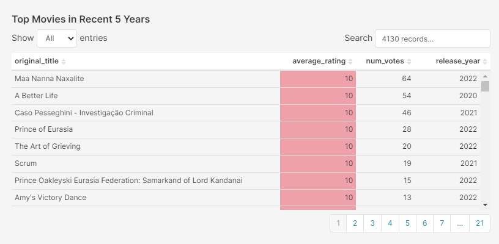

We ranked the movies in the last five years by rating, using number of votes when the rating is the same, and the top ten rows of the table are the highest rated movies requested.

- What directors (with at least 3 movies) have the highest average rating?

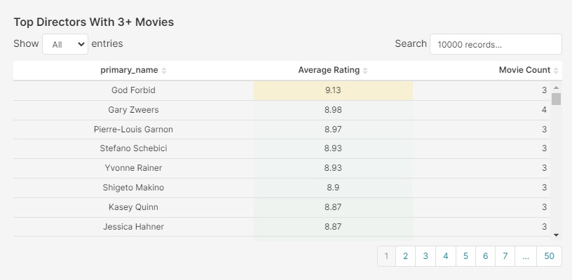

- What actresses (with at least 3 movies) have the highest average rating?

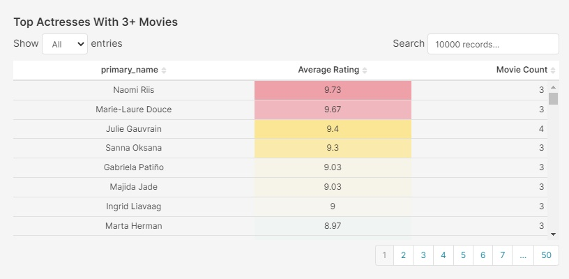

The same as the second question, but the object is changed from the director to the actress. The top 3 actress are Naomi Riis, Marie-Laure Douce, and Julie Gauvrain.

- What actors (with at least 3 movies) have the highest average rating?

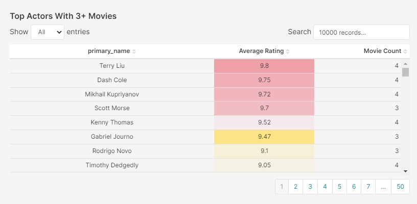

The same as the second question, but the object is changed to the actor. The top three actors are Terry Liu, Dash Cole, and Mikhail Kupriyanov.

- What are the 3 highest rated movies in each genre?

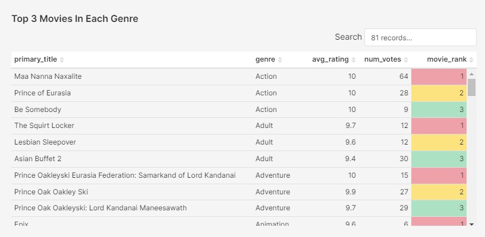

We sorted the movies by genre and listed them in a table, with the top three in each genre listed in order, just look at the table by each of the three rows to see the 3 highest rated movies in each genre.

- What are the highest rated movie genres?

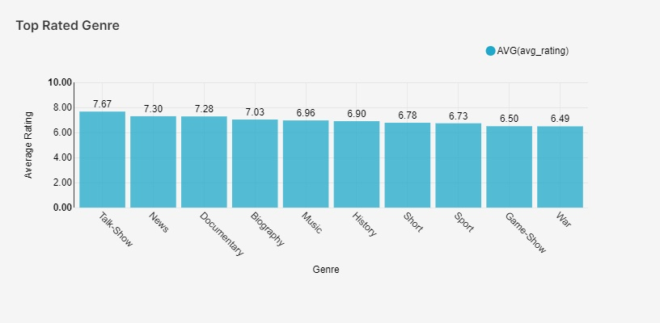

We make a bar chart of the average rating of movies for each genre, showing them from highest to lowest, with the highest rated movie genre on the leftmost side. We can also see the average rating at the top of each bar, and the name of the movie genre on the x-axis.

## Reflection and challenges addressed

In about 200 words describe the challenges that your group faced with their project and how they were addressed.

Include a few sentences that celebrate the aspects of your project of which you are proud.

The most challenging part of this project was that the initial imdb_person_title_roles.csv did not have ids assigned to person and role, which prevented us from extracting these two pieces of information directly and relating them with other tables. Also, there were a lot of duplicate redundant rows in imdb_person_title_roles.csv, which made the data flawed.

Our solution is to use the MAX command for duplicate redundant rows to only keep with the largest id value, so that the other rows can be discarded. For role, we manually assigned ids for director, actor, and actress using ALTER TABLE, since there are only three, this is not a big workload.

But for person, we can't manually assign ids as we did for role, because there are thousands of them. Our approach was to temporarily allow each person to have a different person_id when paired with a different movie title in the subsequent processing. when it came to aggregating the data for each person later, people with the same primary name were aggregated together using GROUP BY - because that would represent the same person. This approach avoids having to deal with data in the middle of the process that is beyond our capabilities, and also ensures the accuracy of the results.

What we are most proud of is that we have learned how to deal with defects in our data. Because in real life, there can't be perfect data exactly like the examples in class. There will always be problems with the raw data we obtain, and it is of utmost importance to address these flaws and ensure that meaningful results are produced. We are proud that we accomplished this.

Also, building from the raw data to the visual product was full of meaning. In the past, we often only used to do the final data analysis; however, working with the data from the raw state was like watching a child grow up, which gave us much sense of accomplishment and made this project so meaningful.